# M280 Assignment2

### 7.5.3.1

1. Instead of summarising the conditional distribution with a boxplot, you could use a frequency polygon. What do you need to consider when using cut_width() vs cut_number()? How does that impact a visualisation of the 2d distribution of carat and price?

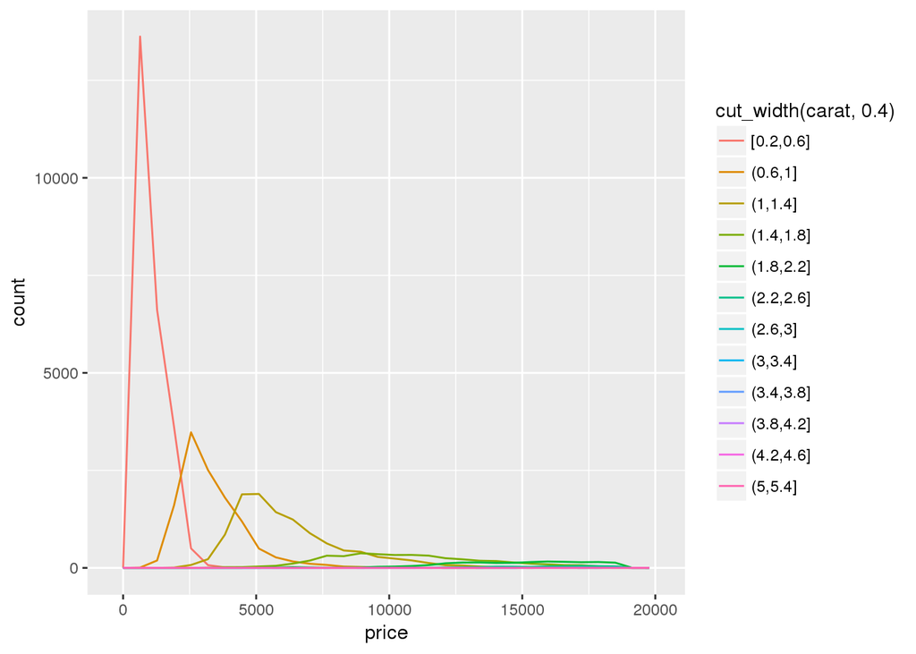

```r
# cut_width
ggplot(diamonds) +
  geom_freqpoly(mapping = aes(x = price,
                              color = cut_width(carat, 0.4)))
```

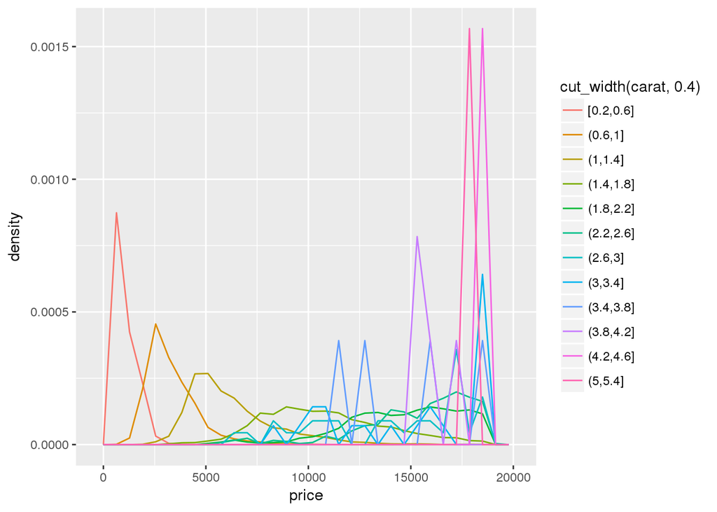

```r
# cut_width with density
ggplot(diamonds) +
  geom_freqpoly(mapping = aes(x = price,
                              y = ..density..,
                              color = cut_width(carat, 0.4)))
```

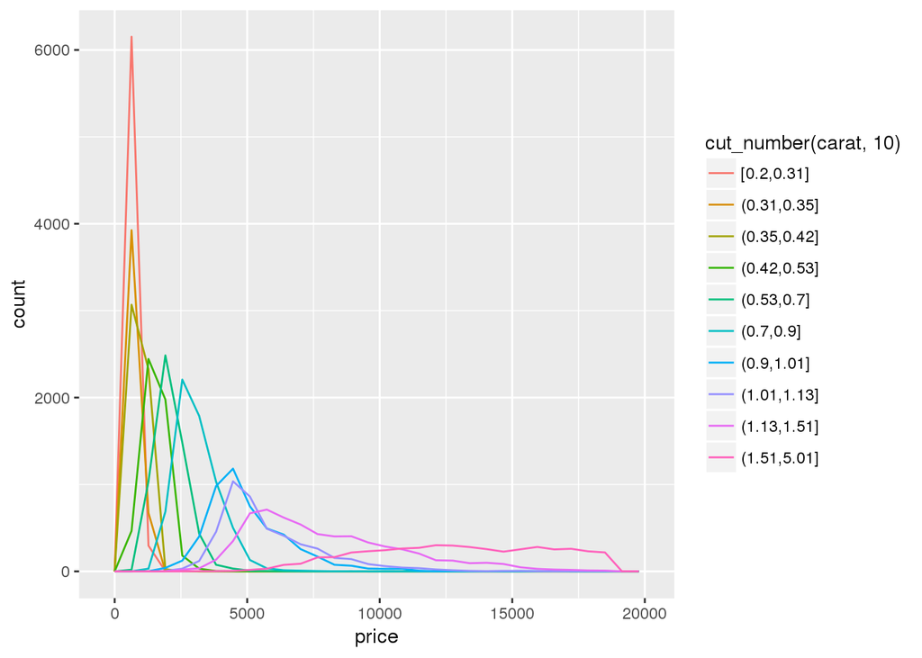

```r
# cut_number
ggplot(diamonds) +
  geom_freqpoly(mapping = aes(x = price,
                              color = cut_number(carat, 10)))
```

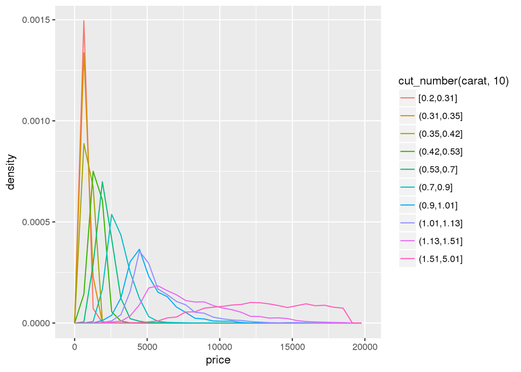

```r
# cut_number with density
ggplot(diamonds) +
  geom_freqpoly(mapping = aes(x = price,
                              y = ..density..,
                              color = cut_number(carat, 10)))
```

- Using `cut_width` cuts the variable range equally, but in each bin, the number of data points may not be equal. The distribution of carat is positivly skewed, which means there are very few diamonds with large carat. This results that in the bins with large carat values, there are few diamonds. The density plot with `cut_width`shows the distribution within each bin, which is very different from the count plot with `cut_width`.
- Using `cut_count` divides the bins with equal data points, thus the widths of bins may be different.In this case, since there are equal numbers in each bin, the density plot share the same shape of count plot.
2. Visualize the distribution of carat, partitioned by price.

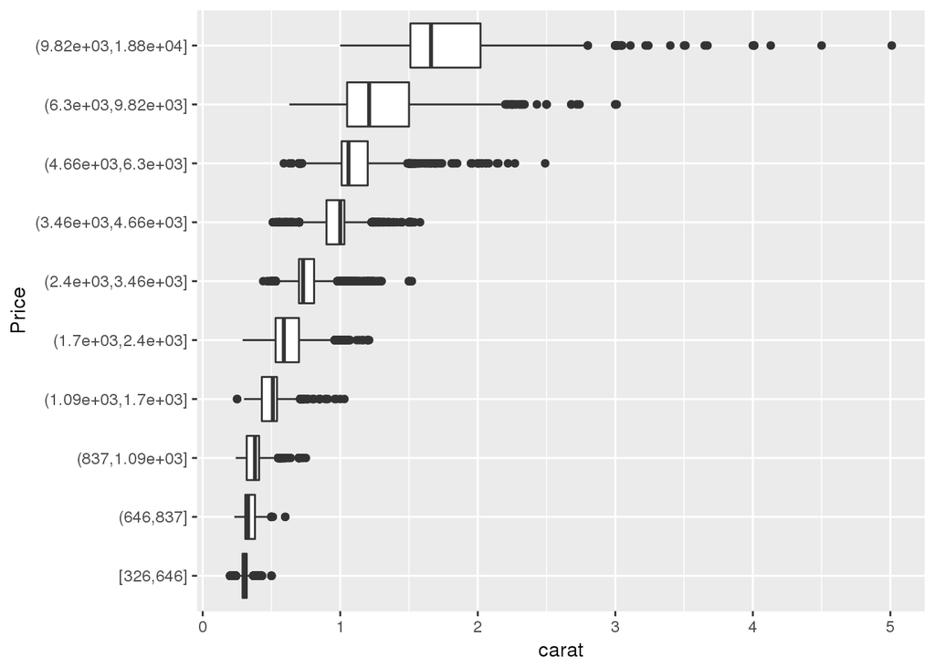

```r
ggplot(diamonds) +
  geom_boxplot(aes(x = cut_number(price, 10),
                   y = carat)) +
  xlab("Price") +
  coord_flip()
```

3. How does the price distribution of very large diamonds compare to small diamonds. Is it as you expect, or does it surprise you?

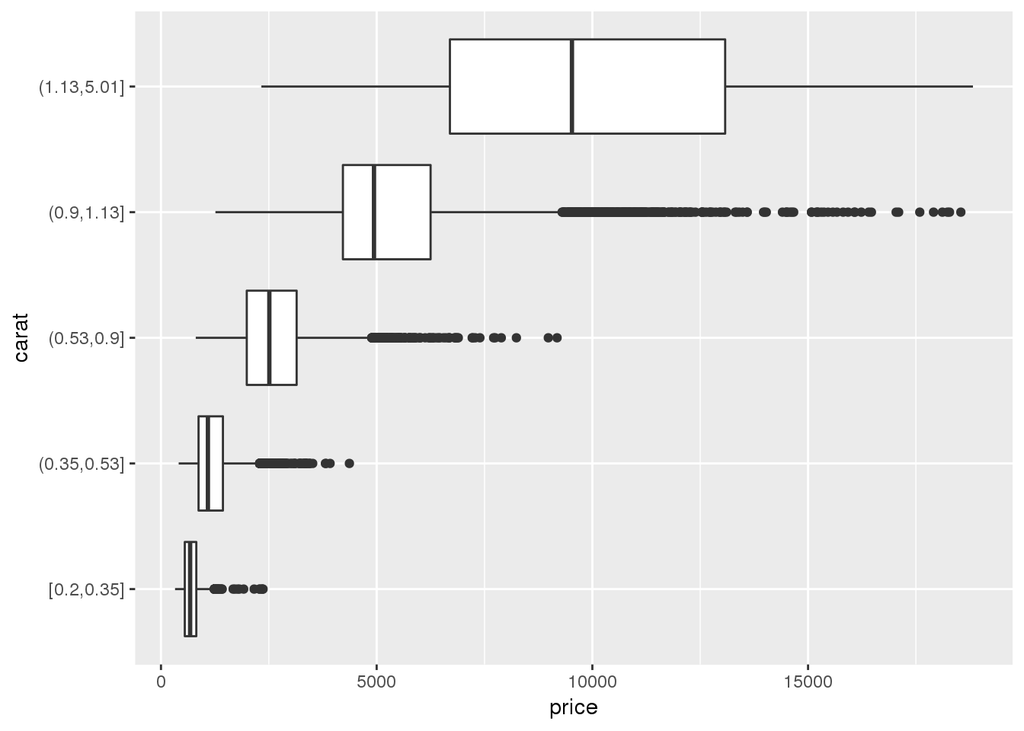

```r
ggplot(diamonds) +
  geom_boxplot(aes(x = cut_number(carat, 5),
                   y = price)) +
  xlab("carat") +
  coord_flip()
```

- Plot the price distribution by partioning on carat. From the medians in the boxplot, we can see the median price of very large diamonds are higher than that of small diamonds. Comparing the range of pricec for each level of carat, the large diamonds is more variable in price and the small diamonds has a narrower price range. This is not surprising, because diamonds with more carat are generally more expensive due to the weight. But they have different level of cut. An ideally cut large diamond may be very expensive and a fair cut large diamond may have lower price because of the cut quality. However, for the small diamonds, the cut quality may not affect price much comparing to the effect of weight.
4. Combine two of the techniques you’ve learned to visualize the combined distribution of cut, carat, and price.

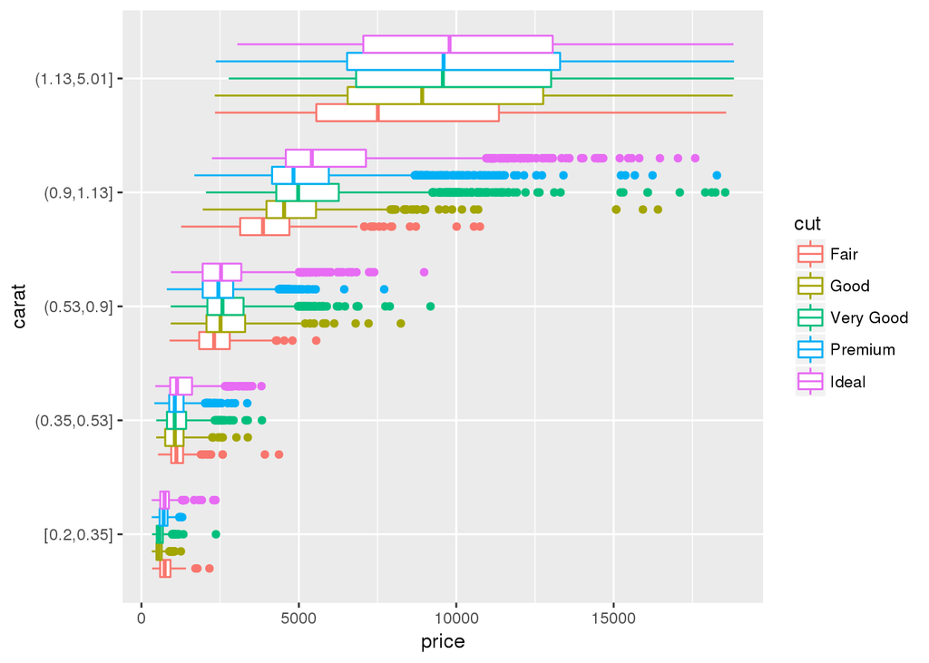

```r
ggplot(diamonds, aes(x = cut_number(carat, 5), y = price, color = cut)) +
  geom_boxplot() +
  xlab("carat") +
  coord_flip()
```

5. Two dimensional plots reveal outliers that are not visible in one dimensional plots. For example, some points in the plot below have an unusual combination of x and y values, which makes the points outliers even though their x and y values appear normal when examined separately. Why is a scatterplot a better display than a binned plot for this case?

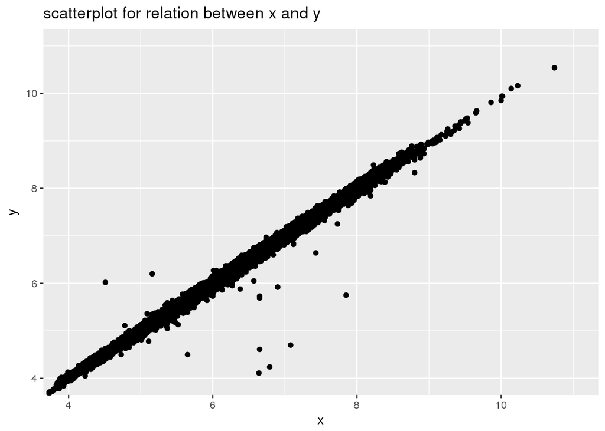

```r
# scatter plot
ggplot(data = diamonds) +
  geom_point(mapping = aes(x = x, y = y)) +
  coord_cartesian(xlim = c(4, 11), ylim = c(4, 11)) +
  labs(
    title = "scatterplot for relation between x and y"
  )
```

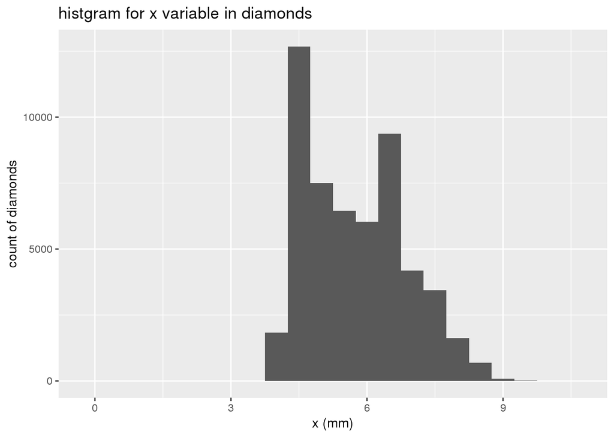

```r
# bin plot for x
ggplot(data = diamonds) +
  geom_histogram(mapping = aes(x = x), binwidth = 0.5) +
  labs(
    title = "histgram for x variable in diamonds",
    x = "x (mm)",
    y = "count of diamonds"
  )
```

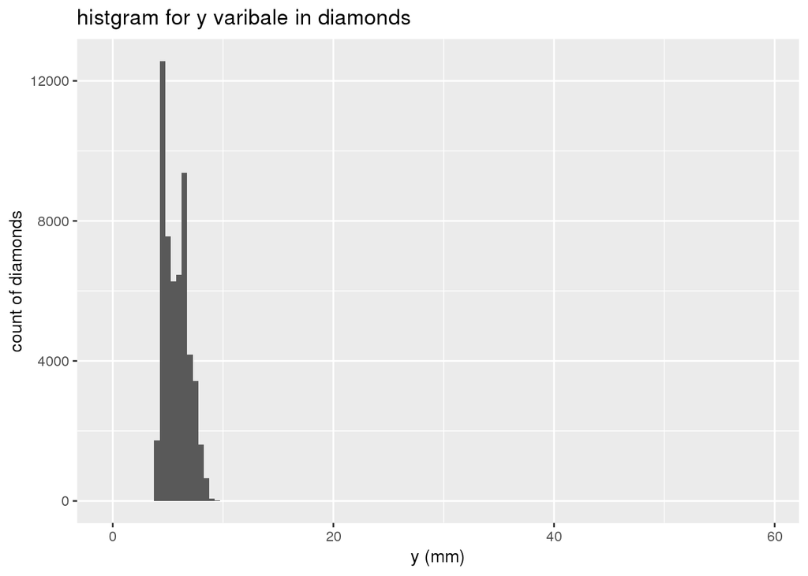

```r
# bin plot for y
ggplot(data = diamonds) +
  geom_histogram(mapping = aes(x = y), binwidth = 0.5) +
  labs(
    title = "histgram for y varibale in diamonds",
    x = "y (mm)",
    y = "count of diamonds"
  )
```

- From the bin plots for x and y, we will regrad the extreme values for x and y as outliers. However, in this example, x and y has a strong linear relation. Large values of x or y do not mean it is a outlier if the corresponding y value is also large. The outliers in scatterplot have normal x or y values, which will not be revealed by bin plots.

## Question 2: Redo HW1 Q2 using tidyverse.

- First read in data files.

```r
gen <- read_tsv(file = "/home/m280-data/hw1/merge-geno.bim",
                col_names = c("Chromosome", "SNP_ID",
                              "Genetic_Distance",
                              "bp",
                              "Allele_1",
                              "Allele_2"))
fam <- read_delim(file = "/home/m280-data/hw1/merge-geno.fam",
                  delim = " ", col_names = c("Fam_ID", "Person_ID",
                                             "Father_ID", "Mother_ID", "Sex",
                                             "Affection_Status"))
```

1. How many persons are in the data set (statisticians call this n)? How many SNPs are in the data set (statisticians call this p)?

```r
gen %>% count()
```

```
## # A tibble: 1 x 1
##         n
##     <int>
## 1 8348674
```

```r
fam %>% count()
```

```
## # A tibble: 1 x 1
##       n
##   <int>
## 1   959
```

```r
gen %>%
  group_by(Chromosome) %>%
  summarise(n = n())
```

```
## # A tibble: 11 x 2
##    Chromosome       n
##         <int>   <int>
##  1          1 1309299
##  2          3 1215399
##  3          5 1090185
##  4          7  980944
##  5          9  732013
##  6         11  815860
##  7         13  602809
##  8         15  491208
##  9         17  477990
## 10         19  393615
## 11         21  239352
```

- This data set contain choromosome 1, 3, 5, 7, 9, 11, 13, 15, 17, 19, 21. There are 1309299 in chromosome 1, 1215399 in chromosome 3, 1090185 in chromosome 5, 980944 in chromosome 7, 732013 in chromosome 9, 815860 in chromosome 11, 602809 in chromosome 13,491208 in chromosome 15, 477990 in chromosome 17, 393615 in chromosome 19 and 239352 in chromosome 21.
3. MAP4 (microtubule-associated protein 4) is a gene on chromosome 3 spanning positions 47,892,180 bp – 48,130,769 bp. How many SNPs are located within MAP4 gene?

```r
gen %>% filter(Chromosome == 3, bp >= 47892180, bp <= 48130769) %>%
  summarise(n = n())
```

```
## # A tibble: 1 x 1
##       n
##   <int>
## 1   894
```

- There are 894 SNPs located within MAP4 gene.
4. Reformat 1:

```r
# create a new empty txt file in current directory
# and make a connection to it
connection <- file("mendel1.txt", open = "a")

# append the first two lines to the file
writeLines("    2.40 = FILE FORMAT VERSION NUMBER", connection)
writeLines("8348674 = NUMBER OF SNPS LISTED HERE", connection)

# close connection to the txt file
close(connection)

# format the output data
bim_reformat <- select(gen, SNP_ID, Chromosome, bp)

# append the output data
write_delim(bim_reformat, "mendel1.txt", delim = ",", append = TRUE)
```

```bash
head mendel1.txt
rm mendel1.txt
```

```
##     2.40 = FILE FORMAT VERSION NUMBER
## 8348674 = NUMBER OF SNPS LISTED HERE
## 1-54490,1,54490
## 1-55550,1,55550
## 1-57033,1,57033
## 1-57064,1,57064
## 1-57818,1,57818
## 1-58432,1,58432
## 1-58448,1,58448
## 1-58814,1,58814
```

Reformat 2:

```r
# format the output data
fam_reformat <- fam %>%
  mutate(Sex = replace(Sex, Sex == 1, "M")) %>%
  mutate(Sex = replace(Sex, Sex == 2, "F")) %>%
  mutate(Affection_Status = replace(Affection_Status, Affection_Status == 0,
                                    "")) %>%
  mutate(Father_ID = replace(Father_ID, Father_ID == "0", ""))%>%
  mutate(Mother_ID = replace(Mother_ID, Mother_ID == "0", "")) %>%
  mutate(Person_ID = str_replace(Person_ID, "T2DG", "")) %>%
  mutate(Father_ID = str_replace(Father_ID, "T2DG", "")) %>%
  mutate(Mother_ID = str_replace(Mother_ID, "T2DG", ""))

# append the output data
write_delim(fam_reformat, "mendel2.txt", delim = ",", append = TRUE)
```

```bash
head -20 mendel2.txt
rm mendel2.txt
```

```
## 2,0200001,,,M,
## 2,0200002,,,F,
## 2,0200003,,,F,
## 2,0200004,,,F,
## 2,0200005,,,M,
## 2,0200006,,,M,
## 2,0200007,,,F,
## 2,0200008,,,F,
## 2,0200009,,,F,
## 2,0200012,,,M,
## 2,0200013,,,M,
## 2,0200018,,,M,
## 2,0200023,,,F,
## 2,0200024,,,M,
## 2,0200027,,,F,
## 2,0200031,0200001,0200015,M,
## 2,0200032,0200001,0200015,F,
## 2,0200033,0200001,0200015,F,
## 2,0200034,0200001,0200015,F,
## 2,0200035,0200001,0200015,F,
```